# Diversity

Tianpei Qian

2023-01-18

### Step 1: read data

You may use the read_lines function to peek the files.

```r
company_hierarchy_file <- 'company_hierarchy.csv'
employee_file <- 'employee.csv'

company_hierarchy <-
  read_csv(
    company_hierarchy_file,
    col_types = list(col_integer(), col_integer(), col_character())
  )
```

```r
employee <-
  read_csv(
    employee_file,
    col_types =
      list(
        col_integer(),
        col_integer(),
        col_double(),
        col_character(),
        col_character(),
        col_double()
      )
  )
```

### Step 2: data cleaning

Join tables, process factors, etc.

```r
employee_combined <-
  employee %>%
  inner_join(company_hierarchy, by = c("employee_id" = "employee_id")) %>%
  mutate(
    sex = factor(sex, levels = c("M", "F")),
    degree_level = factor(degree_level, levels = c("High_School","Bachelor","Master","PhD")),
    dept = factor(dept, levels = c("engineering","HR","marketing","sales", "CEO"))
  )
```

### Step 3: simple exploratory analysis

Mainly check on 1-dimensional data. Look out for outliers/missing values.

```r
employee_combined %>%
  summary()
```

```
##   employee_id     signing_bonus        salary            degree_level  sex
##  Min.   :    40   Min.   :0.0000   Min.   : 60000   High_School:1657   M:6439
##  1st Qu.: 50574   1st Qu.:0.0000   1st Qu.:110000   Bachelor   :2735   F:3561
##  Median : 99244   Median :0.0000   Median :182000   Master     :2786
##  Mean   :100002   Mean   :0.3014   Mean   :189112   PhD        :2822
##  3rd Qu.:149748   3rd Qu.:1.0000   3rd Qu.:255000
##  Max.   :199956   Max.   :1.0000   Max.   :700000
##
##  yrs_experience      boss_id                dept
##  Min.   : 1.000   Min.   :    79   engineering:2696
##  1st Qu.: 2.000   1st Qu.: 55883   HR         :1694
##  Median : 3.000   Median :102712   marketing  :2010
##  Mean   : 3.875   Mean   :103300   sales      :3599
##  3rd Qu.: 5.000   3rd Qu.:152288   CEO        :   1
##  Max.   :34.000   Max.   :199950
##                   NA's   :1
```

First, CEO is a special department with only 1 data point. It probably also contributes the only missing data for boss_id.

```r
employee_combined %>%
  filter(dept == 'CEO')
```

```
## # A tibble: 1 × 8
##   employee_id signing_bonus salary degree_level sex   yrs_experi…¹ boss_id dept
##         <int>         <int>  <dbl> <fct>        <fct>        <dbl>   <int> <fct>
## 1       61554             1 700000 PhD          M                7      NA CEO
## # … with abbreviated variable name ¹yrs_experience
```

We may or may not remove this CEO data point. It won’t cause a big problem if we keep it and handle it with care.

It looks like years of experience may have outliers.

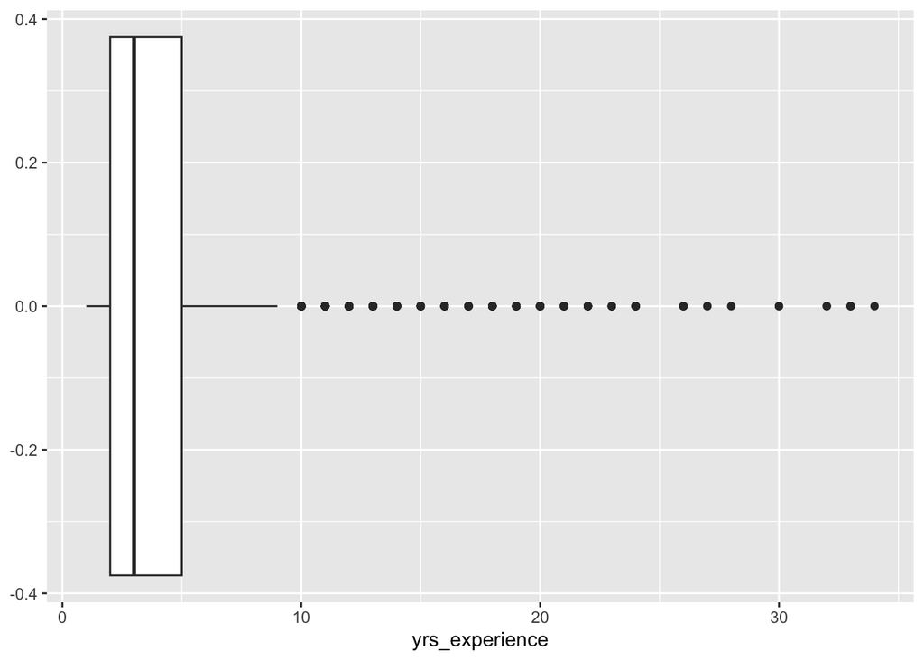

```r
employee_combined %>%
  ggplot(aes(yrs_experience)) +
  geom_boxplot()
```

Most employees have fewer than 10 years of expereince in the company.